# An analysis of data on educational attainment and deprivation in Scotland

Author: T. Hellen

14/04/2022

## Summary

In this report, we investigate data on demographics in Scotland, particularly relating to educational attainment and focusing especially on school attendance, alcohol consumption, employment rate and access to broadband. We also take a look at the relationships between educational attainment, income rate, mental health, drive time to primary and secondary schools and crime rate.

This report uses investigative methods such as histograms, boxplots, normal Q-Q plots, hypothesis tests, scatter graphs and regression models.

## Introduction

The data used in this report are taken from the 2020 Scottish Index of Multiple Deprivation (SIMD), a tool used by government bodies to support policy-making and funding. It is used to help understand the circumstances and outcomes of people living in the most deprived areas in Scotland.

The aim of this report is to understand how certain variables, such as where people live, how people live, the circumstances they live in and the resources available to them affect educational attainment.

The data include various variables for different “data zones” in Scotland. Data zones are small geographical areas typically containing a population of between 500 and 1000 people. There are 6,976 data zones in total in Scotland, but the analysis in this report focuses on a sample of 400 of them, of which 100 are from the Glasgow City, 100 are from City of Edinburgh, and 200 are from elsewhere in Scotland.

The data set contains many different variables, of which we will focus in particular on:

- Attainment - the attainment of school leavers
- Attendance - the percentage of school pupil attendance
- Alcohol - hospital stays related to alcohol use
- Employment Rate - the percentage of people who are employment deprived
- Broadband - the percentage of premises without access to superfast broadband, in this case at least 30Mb/s download speed
- Income Rate - the percentage of people who are income deprived
- Mental Health - the proportion of population being prescribed drugs for anxiety, depression or psychosis
- Drive Time - the average drive time to a primary school and secondary school in minutes
- Crime Rate - the recorded crimes of violence, sexual offences, domestic housebreaking, vandalism, drugs offences and common assault per 10,000 people

This study helps the government understand where they need to direct their funding. It shows which variables affect educational attainment, to help parents, students and teachers in improving and optimising grades achieved when students leave school. It shows the cause and effect of different attainment in different areas.

## Methods

We compare attainment to the further variables mentioned above by using another matrix of scatter graphs, and calculating Pearson sample correlation coefficients to make note of any noticeable and sizeable correlations, then compare them in histograms, using frequency density for ease of comparability.

## Results

### Comparing educational attainment between the cities of Glasgow and Edinburgh

In this section, we focus on the available data for Glasgow and Edinburgh, for each of which the data set contains 100 observations (data zones). For these data zones, the following box plots summarise the distribution of the educational attainment variable:

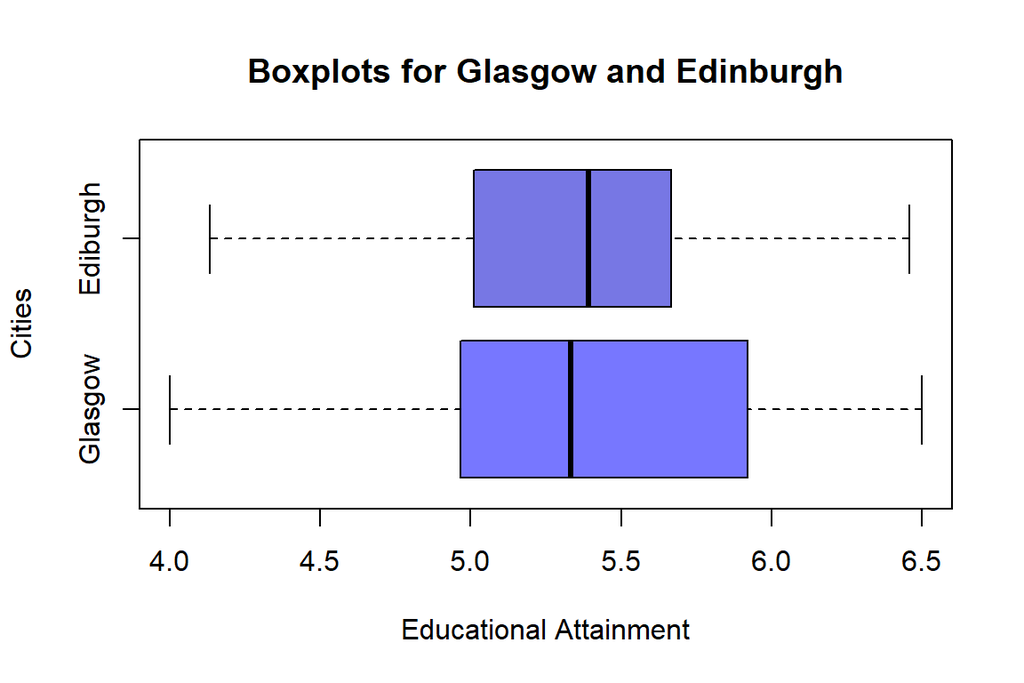

Figure 1: The distribution of educational attainment in Glasgow and Edinburgh

As further numerical summaries of overall attainment and variability in attainment, we compute the sample means and variances respectively. The sample mean attainments for Glasgow and Edinburgh are $\bar{x}_G=$ 5.3666 and $\bar{x}_E =$ 5.3941, and the sample variances are $s^2_G =$ 0.2038 and $s^2_E =$ 0.3772.

To investigate the distributions in more detail, the following shows histograms of the educational attainment in Glasgow and Edinburgh, along with normal Q-Q plots for the data.

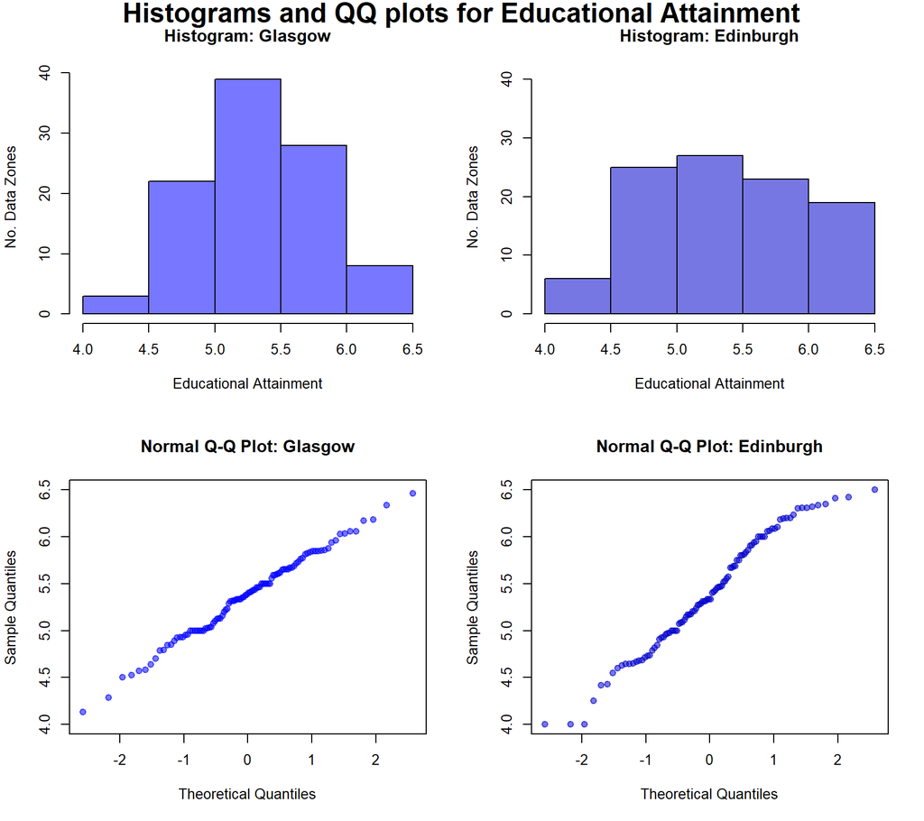

Figure 2: Histograms and accompanying normal QQ plots of educational attainment for Glasgow and Edinburgh

The histograms show with more clarity Glasgow’s normal distribution.Fewer of Glasgow’s students attain high grades than Edinburgh, and more of them achieve middling grades between 5.0 and 5.5.

From the Q-Q plots we can see a couple outliers on both ends for each city, where some students will have gotten abnormally high or low grades. We also see that Edinburgh’s distribution doesn’t quite fit the suggested model. Edinburgh has curvature in opposite directions at both ends, suggesting that the sample distribution has lighter tails than the theoretical distribution.

### Investigating the relationship between educational attainment and other variables

In this section we consider all of the data zones.

The following plot shows the relationship between the various variables described in the Introduction section above.

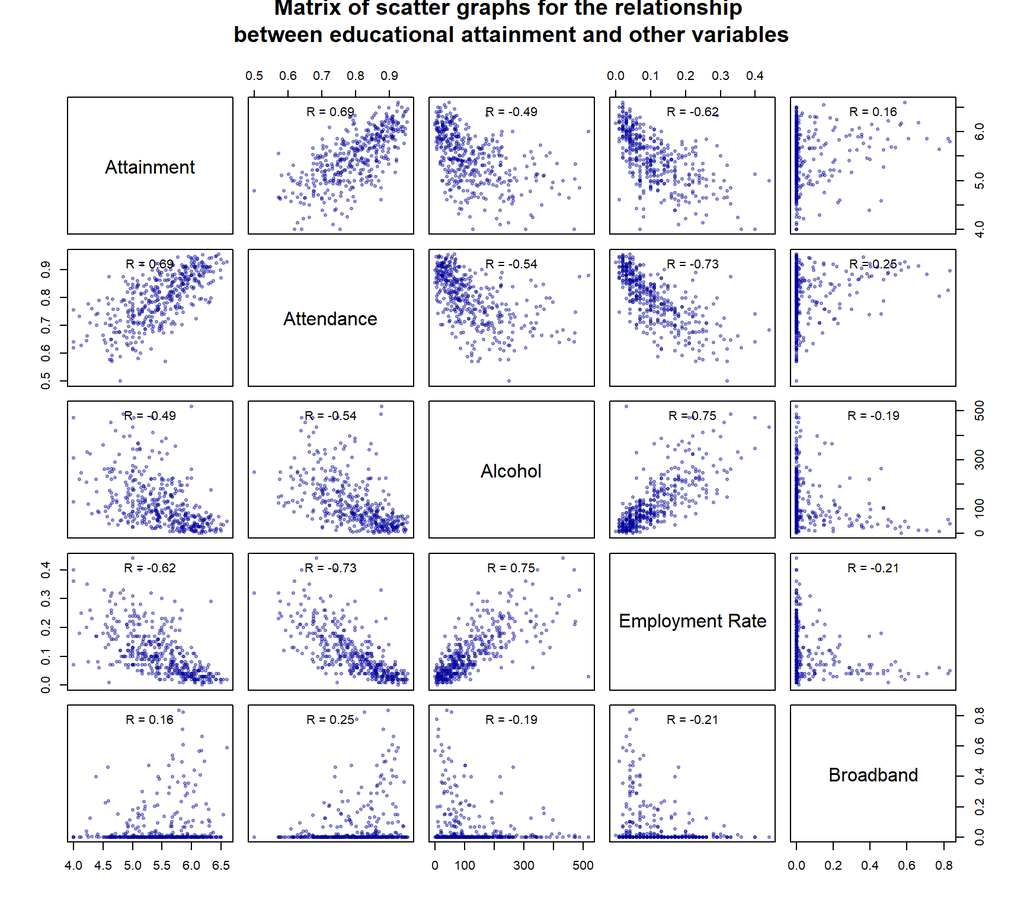

Figure 3: Matrix scatterplot for the relationship between educational attainment, attendance, alcohol, employment rate and broadband

The corresponding numerical values for the Pearson sample correlation coefficients between these variables are

|  | Attainment | Attendance | Alcohol | Employment Rate | Broadband |
| --- | --- | --- | --- | --- | --- |
| Attainment | 1.0000 | 0.6912 | -0.4937 | -0.6177 | 0.1593 |
| Attendance | 0.6912 | 1.0000 | -0.5401 | -0.7283 | 0.2459 |
| Alcohol | -0.4937 | -0.5401 | 1.0000 | 0.7550 | -0.1875 |
| Employment Rate | -0.6177 | -0.7283 | 0.7550 | 1.0000 | -0.2125 |
| Broadband | 0.1593 | 0.2459 | -0.1875 | -0.2125 | 1.0000 |

We can conclude that attainment and attendance have a strong positive correlation - the higher a student’s attendance, the higher the grades attained when they leave school. We see that number of hospital stays and percentage of unemployed people are positively correlated, and that these both negatively affect attendance and educational attainment. Broadband speed has a negligible affect on any of the other variables, although it does have a small positive correlation with attainment.

We plot again as follows the attainment rate versus the attendance, with an added line of best fit for a regression model.

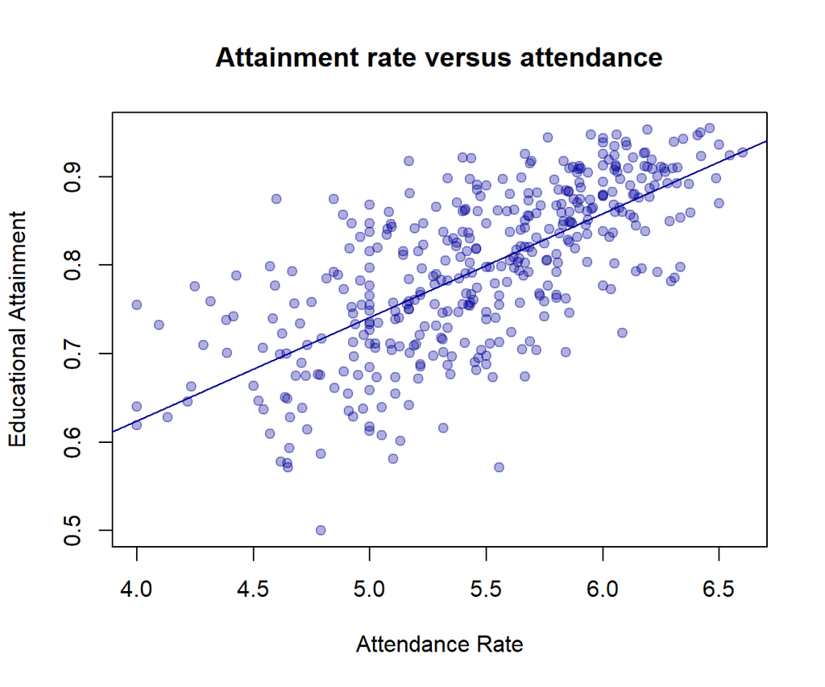

### A brief investigation into the relationship between educational attainment and further variables

In this section we consider the relationship between educational attainment, income rate, mental health, drive primary and drive secondary, and crime rate.

The following plot shows the relationship between the various variables described above.

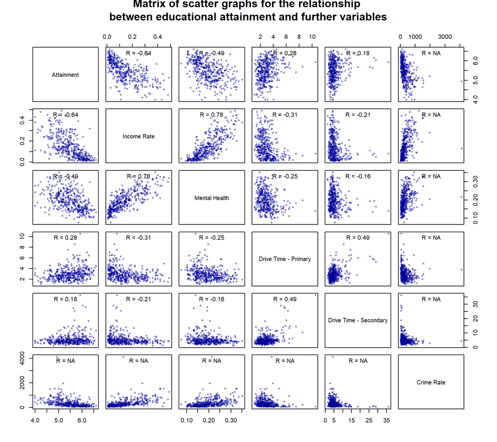

Figure 5: Matrix scatterplot for the relationship between educational attainment, income rate, mental health, drive time - primary, drive time - secondary and crime rate

|  | Attainment | Income Rate | Mental Health | Drive Time - Primary | Drive Time - Secondary | Crime Rate |
| --- | --- | --- | --- | --- | --- | --- |
| Attainment | 1.00 | -0.64 | -0.49 | 0.28 | 0.18 | NA |
| Income Rate | -0.64 | 1.00 | 0.78 | -0.31 | -0.21 | NA |
| Mental Health | -0.49 | 0.78 | 1.00 | -0.25 | -0.16 | NA |
| Drive Time - Primary | 0.28 | -0.31 | -0.25 | 1.00 | 0.49 | NA |
| Drive Time - Secondary | 0.18 | -0.21 | -0.16 | 0.49 | 1.00 | NA |
| Crime Rate | NA | NA | NA | NA | NA | NA |

There is a weak correlation between both drive times and attainment, which could be due to outliers.

The following plots take a closer look at attainment, income rate and mental health through histograms.

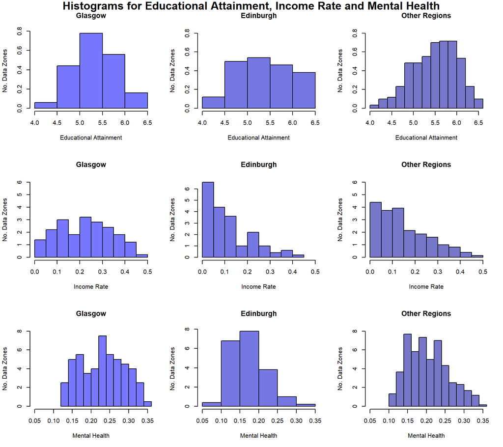

Figure 6: Histograms of educational attainment, income rate and mental health for Glasgow, Edinburgh and other regions

## Conclusions

We have investigated various characteristics of data available for geographical areas in Scotland called “data zones”, focusing in particular on Glasgow and Edinburgh. Overall, Edinburgh’s students attain higher grades than Glasgow, which has a slightly lower mean.

Attendance has the biggest effect on attainment from looking at the scatterplots - the more a student attends class, the higher grades they get when they leave school.

There are some limitations of the current study. The data is only from one year, looking at data from a spread of several years could allow us to compare which variables affect attainment. The data we are looking at doesn’t specify the ages, this would be useful in looking at parents effects on student’s attainment, and what could be due to other circumstances.

A future study could investigate how government funding and charities can help with disadvantages that affect a student’s education. It could investigate student’s downtime and attitude towards education. It could conduct further hypothesis tests to confirm if the noted relationships are significant.

## Appendix

The R code to produce the analysis and plots in this report is as follows:

```r
knitr::opts_chunk$set(echo = TRUE)
scottish.data <- read.csv("scottishData.csv", header=TRUE)

glasgow=subset(scottish.data, Council_area=="Glasgow City")
edinburgh=subset(scottish.data, Council_area=="City of Edinburgh")
#glasgow and edinburgh against attainment
boxplot(edinburgh[,c(18)],glasgow[,c(18)],
range=0,col=(c('#0000FF88','#0000CC88')), names=c('Glasgow','Ediburgh'), xlab='Educational Attainment', ylab='Cities', main='Boxplots for Glasgow and Edinburgh', horizontal=TRUE)

m.glas=mean(glasgow[,c(18)])
m.edin=mean(edinburgh[,c(18)])
v.glas=var(glasgow[,c(18)])
v.edin=var(edinburgh[,c(18)])
par(mfrow=c(2,2))
hist(glasgow[,c(18)], xlab='Educational Attainment', ylab='No. Data Zones', main='Histogram: Glasgow', col='#0000FF88')
hist(edinburgh[,c(18)], xlab='Educational Attainment', ylab='No. Data Zones', main='Histogram: Edinburgh', col='#0000CC88', ylim=c(0,40))
mtext('Histograms and QQ plots for Educational Attainment', side=3, line=-1.5, outer=TRUE, font=2, cex=1.6)
qqnorm(glasgow[,c(18)], col='#0000FF88', pch=19, main='Normal Q-Q Plot: Glasgow', ylim=c(4.0,6.5))
qqnorm(edinburgh[,c(18)], col='#0000CC88', pch=19, main='Normal Q-Q Plot: Edinburgh')

test=var.test(glasgow$Attainment, edinburgh$Attainment, alternative = 'two.sided')
chi_G=(99*v.glas**2)/(m.glas**2)
chi_E=(99*v.edin**2)/(m.edin**2)

upper.panel<-function(x, y){
  points(x,y, pch=20, col=c('#00009950'))
  r <- round(cor(x, y, method=c("pearson")), digits=2)
  txt <- paste0("R = ", r)
  usr <- par("usr"); on.exit(par(usr))
  par(usr = c(0, 1, 0, 1))
  text(0.5, 0.9, txt)
}
pairs(scottish.data[,c(18,17,11,8,31)],upper.panel = upper.panel, lower.panel = upper.panel, labels=c('Attainment','Attendance','Alcohol','Employment Rate','Broadband'), main='Matrix of scatter graphs for the relationship \nbetween educational attainment and other variables')

r <- round(cor(scottish.data[,c(18,17,11,8,31)], scottish.data[,c(18,17,11,8,31)], method=c("pearson")), digits=4)
names_for_table=c('Attainment', 'Attendance', 'Alcohol', 'Employment Rate', 'Broadband')
rownames(r)=names_for_table
colnames(r)=names_for_table
library(knitr)
kable(r, align = 'c')
plot(scottish.data[,c(18)],scottish.data[,c(17)], xlab='Attendance Rate', ylab='Educational Attainment', col=c('#00009950'), pch=19, main='Attainment rate versus attendance')
abline(lm(scottish.data[,c(17)] ~ scottish.data[,c(18)]), col=c('#000099'))
regressiondata=summary(lm(scottish.data[,c(18)] ~ scottish.data[,c(17)]))
regcoefficients=regressiondata$coefficients
B0=regcoefficients[c(1),c(1)]
B1=regcoefficients[c(2),c(1)]
t=regcoefficients[c(2),c(3)]
p=regcoefficients[c(2),c(4)]


upper.panel<-function(x, y){
  points(x,y, pch=20, col=c('#00009950'))
  r <- round(cor(x, y, method=c("pearson")), digits=2)
  txt <- paste0("R = ", r)
  usr <- par("usr"); on.exit(par(usr))
  par(usr = c(0, 1, 0, 1))
  text(0.5, 0.9, txt)
}
pairs(scottish.data[,c(18,6,14,25,27,33)],upper.panel = upper.panel, lower.panel = upper.panel, labels=c('Attainment','Income Rate','Mental Health','Drive Time - Primary','Drive Time - Secondary', 'Crime Rate'), main='Matrix of scatter graphs for the relationship \nbetween educational attainment and further variables')

r <- round(cor(scottish.data[,c(18,6,14,25,27,33)], scottish.data[,c(18,6,14,25,27,33)], method=c("pearson")), digits=2)
names_for_table=c('Attainment', 'Income Rate','Mental Health','Drive Time - Primary','Drive Time - Secondary', 'Crime Rate')
rownames(r)=names_for_table
colnames(r)=names_for_table
library(knitr)
kable(r, align = 'c')
elsewhere=subset(scottish.data, Council_area!="City of Edinburgh", Council_area!='Glasgow City')
par(mfrow=c(3,3))
#first row attainment
hist(glasgow[,c(18)], xlab='Educational Attainment', ylab='No. Data Zones', main='Glasgow', col='#0000FF88', freq=FALSE)
hist(edinburgh[,c(18)], xlab='Educational Attainment', ylab='No. Data Zones', main='Edinburgh', col='#0000CC88', freq=FALSE, ylim=c(0.0,0.8))
hist(elsewhere[,c(18)], xlab='Educational Attainment', ylab='No. Data Zones', main='Other Regions', col='#00009988', freq=FALSE, ylim=c(0.0,0.8))

#second row income rate
hist(glasgow[,c(6)], xlab='Income Rate', ylab='No. Data Zones', main='Glasgow', col='#0000FF88', freq=FALSE, ylim=c(0,6))
hist(edinburgh[,c(6)], xlab='Income Rate', ylab='No. Data Zones', main='Edinburgh', col='#0000CC88', freq=FALSE, xlim=c(0.0,0.5))
hist(elsewhere[,c(6)], xlab='Income Rate', ylab='No. Data Zones', main='Other Regions', col='#00009988', freq=FALSE, ylim=c(0,6))

#third row mental health
hist(glasgow[,c(14)], xlab='Mental Health', ylab='No. Data Zones', main='Glasgow', col='#0000FF88', freq=FALSE, xlim=c(0.05,0.35), ylim=c(0,8))
hist(edinburgh[,c(14)], xlab='Mental Health', ylab='No. Data Zones', main='Edinburgh', col='#0000CC88', freq=FALSE, xlim=c(0.05,0.35))
hist(elsewhere[,c(14)], xlab='Mental Health', ylab='No. Data Zones', main='Other Regions', col='#00009988', freq=FALSE, xlim=c(0.05,0.35), ylim=c(0,8))

mtext('Histograms for Educational Attainment, Income Rate and Mental Health', side=3, line=-1.5, outer=TRUE, font=2, cex=1.2)
#qqnorm(glasgow[,c(18)], col='#0000FF88', pch=19, main='Normal Q-Q Plot: Glasgow')
#qqnorm(edinburgh[,c(18)], col='#0000CC88', pch=19, main='Normal Q-Q Plot: Edinburgh')
```